# Simon Ghyselincks

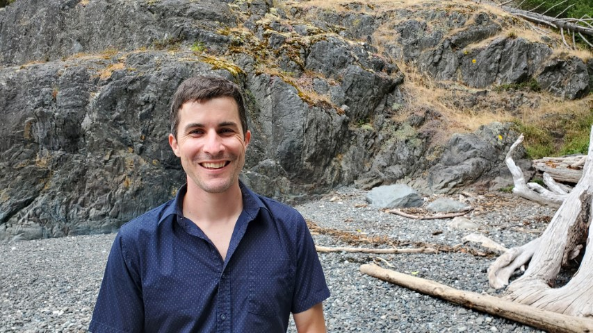

Welcome to my personal site! I’m Simon Ghyselincks, currently a 5th-year Engineering Physics student at the University of British Columbia (UBC), with a minor in Computer Science. I am studying a cross-disciplinary blend of engineering, computer science, and applied mathematics. What I really love is coding to solve tough problems in robotics, machine learning, signal processing, and more.

## Academics and Projects

This summer 2024 I will be working in a reasearch position to develop a GNN for modeling weather patterns and predicting extreme weather events. I am also continuing to develop our Engineering Physics capstone project “Learning to Balance” which explores the application of reinforcement learning to a reaction wheel robot with complex dynamics. Read more about my projects here.

## Outside the Lab

Feel free to connect with me on LinkedIn or check out my [GitHub projects](https://github.com/chipnbits).

## My Journey

I wasn’t always so academically focused. In fact, I had a ten year career in forestry where I planted over *2 million* trees along with a variety of other projects. I also spent some years living in the Peruvian working as a travel guide and translator.

I came back to study at UBC in 2020 to revisit my interest in science and technology, after an injury required me to change lifestyles. It has been a challenging but rewarding journey, and I am excited to see where it takes me next.

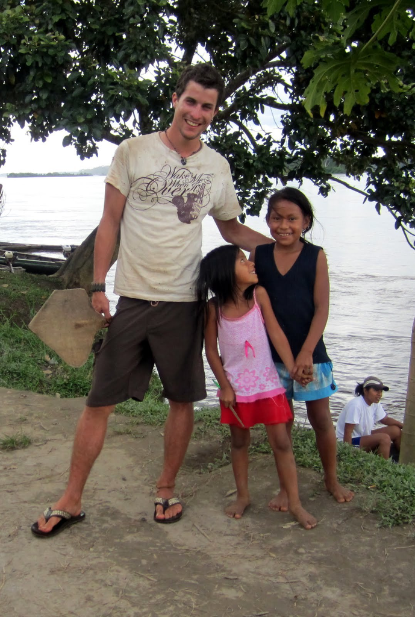

Amazon, Peru

[figure not shown]

Remote Helicopter Forestry Work